# K-Means Clustering

Fakhri Ilham (18523060) & Muhammad Farhan (18523114)

K-MEANS Clustering

Dataset yang dipilih adalah “mall_customers” Kami mencoba melakukan clustering variable annual_income dan score_spending terhadap Gender

#STEP 1 : import data dari xlsx

```r
library(readxl)
mall_customers <- read_excel("Mall_Customers.xlsx")
data("mall_customers")
summary(mall_customers)
```

```
##    CustomerID        Gender               Age        Annual Income (k$)
##  Min.   :  1.00   Length:200         Min.   :18.00   Min.   : 15.00
##  1st Qu.: 50.75   Class :character   1st Qu.:28.75   1st Qu.: 41.50
##  Median :100.50   Mode  :character   Median :36.00   Median : 61.50
##  Mean   :100.50                      Mean   :38.85   Mean   : 60.56
##  3rd Qu.:150.25                      3rd Qu.:49.00   3rd Qu.: 78.00
##  Max.   :200.00                      Max.   :70.00   Max.   :137.00
##  Spending Score (1-100)
##  Min.   : 1.00
##  1st Qu.:34.75
##  Median :50.00
##  Mean   :50.20
##  3rd Qu.:73.00
##  Max.   :99.00
```

#STEP 2 : untuk dapat melakukan clustering, kita asumsikan bahwa kita menghilangkan variable “Gender”[col 2] dari dataset utama (mall_customers) untuk dimasukkan ke variabel baru (mall_customers.class) kemudian kita juga membuat variable mall_customers.new untuk menampung data yang hendak di clustering

data yang dipilih untuk dilakukan clustering adalah : annual_income dan score_spending

lalu dilakukan clustering dengan menentukkan cluster = 2

```r
mall_customers.new <- mall_customers[,4:5]
mall_customers.class <- mall_customers[, 2]
set.seed(1356)
result <- kmeans(mall_customers.new, 2)
```

#STEP 3 : memvisualisasikan hasil clustering dengan plot

[figure not shown]

```r
par(mfrow=c(2,2), mar=c(5,4,2,2))
plot(mall_customers.new[, c(1,2)], col=result$cluster)
plot(mall_customers.new[, c(1,2)], col=mall_customers)
```

#STEP 4: kita mengevaluasi cost function yang disebut sebagai distortion function. Di sini nilai distortion pada iterasi terakhir dapat dilihat melalui tot.withinss.

```r
result$tot.withinss
```

```
## [1] 183257.9
```

#STEP 5: Untuk melihat nilai apa saja yang dikembalikan oleh fungsi kmeans, dapat dilihat melalui

```r
attributes(result)$names
```

```
## [1] "cluster"      "centers"      "totss"        "withinss"     "tot.withinss"
## [6] "betweenss"    "size"         "iter"         "ifault"
```

#STEP 6: visualisasi dengan menggunakan ggplot disini kami melakukan rename column untuk memudahkan pemanggilan column

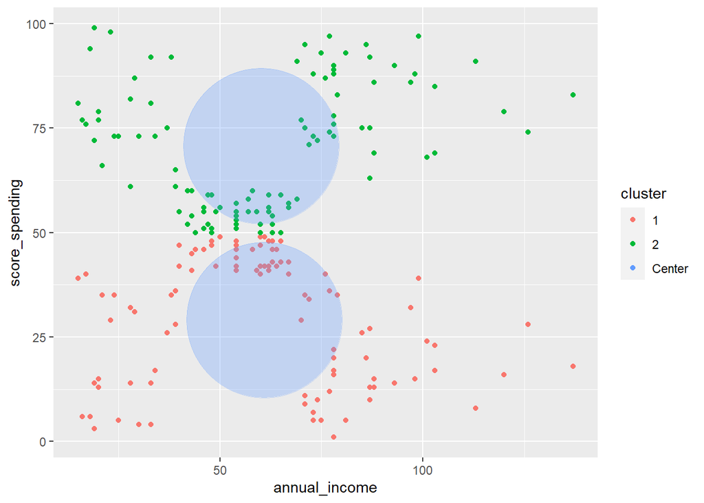

```r
mall_customers.new$cluster <- factor(result$cluster)
centers <- as.data.frame(result$centers)
colnames(mall_customers.new)[1] <- "annual_income"
colnames(mall_customers.new)[2] <- "score_spending"

colnames(centers)[1] <- "annual_income"
colnames(centers)[2] <- "score_spending"
library(ggplot2)
ggplot() +
  geom_point(data=mall_customers.new, aes(x=annual_income, y=score_spending,color=cluster))  +
  geom_point(data=centers, aes(x=annual_income, y=score_spending, color="Center"),
             size=52, alpha=.3, show.legend = FALSE)
```